# Работа с пропущенными значениями

Зарманбетов Ахмед

### Пропущенные значения

С самого первого занятия мы с вами говорили про пропущенные значения. В R они отображаются как `NA`. В реальных данных часто приходится сталкиваться с ними. Например, если проводить опрос людей, то некоторые не захотят говорить о своей заработной плате. Это и есть пропущенное значение.

### Базовая работа с пропущенными значениями

Мы уже знаем функцию `is.na`. Она выдает логический ответ на вопрос: “Является ли значение пропущенным?”. Она может работать с массивами.

```r
x <- c(1, NA, 3, NA, NA, 5)
is.na(x)
```

```
## [1] FALSE  TRUE FALSE  TRUE  TRUE FALSE
```

Но есть и другие инструменты. Они находятся в пакете `naniar`. Давайте установим и подгрузим его и остальные пакеты.

```r
# install.packages("naniar")
library(naniar)
library(tidyr)
library(dplyr)
```

Наши переменные в наборе данных это массивы. И всегда хочется узнать, есть ли пропущенные значения в этой переменной. Для этого можно использовать функцию `any_na`. Она выдает логический ответ на вопрос: “Есть ли в массиве пропущенные значения?”

```r
any_na(x)
## [1] TRUE
y <- 1:5
any_na(y)
## [1] FALSE
```

Если пропущенные значения есть, то хотелось бы знать их количество, а лучше долю.

```r
n_miss(x)
## [1] 3
prop_miss(x)
## [1] 0.5
```

`NaN` считается пропущенным значением, а бесконечность `Inf` не считается.

```r
any_na(NaN)
## [1] TRUE
any_na(Inf)
## [1] FALSE
```

Будет использовать функцию для генерации массива с пропущенными значениями.

```r
generate <- function(prop_na, len = 1000){
  x <- round(seq(-100, 100, length.out = len), 4)
  n <- length(x)
  y <- sample(c(NA, x), size = len, replace = TRUE, prob = c(prop_na, rep((1-prop_na)/n, n)))
  return(y)
}
```

Сгенерим набор данных с 3 переменными.

```r
df <- tibble(x = generate(0.05),
             y = generate(0.07),
             z = generate(0.02))
```

С помощью функции `n_miss` можно узнать количество пропущенных значений во всем наборе данных или в отдельной переменной.

```r
n_miss(df)
## [1] 152
n_miss(df$x)
## [1] 52
```

Обратная функция `n_complete` показывает сколько значений у нас есть о всем наборе данных или в отдельной переменной.

```r
n_complete(df)
## [1] 2848
n_complete(df$x)
## [1] 948
```

А функции `prop_miss` и `prop_complete` показывают долю пропущенных и имеющихся значений.

```r
prop_miss(df)
## [1] 0.05066667
prop_complete(df)
## [1] 0.9493333

prop_miss(df$x)
## [1] 0.052
prop_complete(df$x)
## [1] 0.948
```

### Различные статистики для пропущенных значений

Не хотелось бы использовать эти функции в случае, когда у нас много переменныех. Есть готовые решения для этого. Функция `miss_var_summary` показывает статистику для переменных, а функция `miss_case_summary` для наблюдений. Давайте попробуем эти функции на датасете `airquality` из пакета `naniar`.

```r
glimpse(airquality)
```

```
## Observations: 153
## Variables: 6
## $ Ozone   <int> 41, 36, 12, 18, NA, 28, 23, 19, 8, NA, 7, 16, 11, 14, 18…
## $ Solar.R <int> 190, 118, 149, 313, NA, NA, 299, 99, 19, 194, NA, 256, 2…
## $ Wind    <dbl> 7.4, 8.0, 12.6, 11.5, 14.3, 14.9, 8.6, 13.8, 20.1, 8.6, …
## $ Temp    <int> 67, 72, 74, 62, 56, 66, 65, 59, 61, 69, 74, 69, 66, 68, …
## $ Month   <int> 5, 5, 5, 5, 5, 5, 5, 5, 5, 5, 5, 5, 5, 5, 5, 5, 5, 5, 5,…
## $ Day     <int> 1, 2, 3, 4, 5, 6, 7, 8, 9, 10, 11, 12, 13, 14, 15, 16, 1…
```

Функция `miss_var_summary` выдает *tibble- фрейм* в котором есть переменные:

- `variable` – переменная
- `n_miss` – количество пропущенных значений
- `pct_miss` – процент пропущенных значений

Такой фрейм отсортирован по столбцу `n_miss`.

```r
miss_var_summary(airquality)
```

```
## # A tibble: 6 x 3
##   variable n_miss pct_miss
##   <chr>     <int>    <dbl>
## 1 Ozone        37    24.2
## 2 Solar.R       7     4.58
## 3 Wind          0     0
## 4 Temp          0     0
## 5 Month         0     0
## 6 Day           0     0
```

Функция `miss_case_summary` выдает *tibble- фрейм* в котором есть переменные:

- `case` – номер наблюдения
- `n_miss` – количество пропущенных значений
- `pct_miss` – процент пропущенных значений

Такой фрейм так же отсортирован по столбцу `n_miss`.

```r
miss_case_summary(airquality)
```

```
## # A tibble: 153 x 3
##     case n_miss pct_miss
##    <int>  <int>    <dbl>
##  1     5      2     33.3
##  2    27      2     33.3
##  3     6      1     16.7
##  4    10      1     16.7
##  5    11      1     16.7
##  6    25      1     16.7
##  7    26      1     16.7
##  8    32      1     16.7
##  9    33      1     16.7
## 10    34      1     16.7
## # … with 143 more rows
```

Эти функции можно применять с pipe’ом (`%>%`).

```r
airquality %>%
  group_by(Month) %>%
  miss_var_summary()
```

```
## # A tibble: 25 x 4
## # Groups:   Month [5]
##    Month variable n_miss pct_miss
##    <int> <chr>     <int>    <dbl>
##  1     5 Ozone         5     16.1
##  2     5 Solar.R       4     12.9
##  3     5 Wind          0      0
##  4     5 Temp          0      0
##  5     5 Day           0      0
##  6     6 Ozone        21     70
##  7     6 Solar.R       0      0
##  8     6 Wind          0      0
##  9     6 Temp          0      0
## 10     6 Day           0      0
## # … with 15 more rows
```

```r
airquality %>%
  group_by(Month) %>%
  miss_case_summary()
```

```
## # A tibble: 153 x 4
## # Groups:   Month [5]
##    Month  case n_miss pct_miss
##    <int> <int>  <int>    <dbl>
##  1     5     5      2       40
##  2     5    27      2       40
##  3     5     6      1       20
##  4     5    10      1       20
##  5     5    11      1       20
##  6     5    25      1       20
##  7     5    26      1       20
##  8     5     1      0        0
##  9     5     2      0        0
## 10     5     3      0        0
## # … with 143 more rows
```

Функции `miss_var_table` и `miss_case_table` дают более общую информацию. Например, первая показывает количество переменных, в которых нет пропущенных значений или есть определенное количество.

```r
miss_var_table(airquality)
```

```
## # A tibble: 3 x 3
##   n_miss_in_var n_vars pct_vars
##           <int>  <int>    <dbl>
## 1             0      4     66.7
## 2             7      1     16.7
## 3            37      1     16.7
```

```r
miss_case_table(airquality)
```

```
## # A tibble: 3 x 3
##   n_miss_in_case n_cases pct_cases
##            <int>   <int>     <dbl>
## 1              0     111     72.5
## 2              1      40     26.1
## 3              2       2      1.31
```

Эти функции так же можно использовать с pipe’ом (`%>%`).

```r
airquality %>%
  group_by(Month) %>%
  miss_var_table()
```

```
## # A tibble: 12 x 4
## # Groups:   Month [5]
##    Month n_miss_in_var n_vars pct_vars
##    <int>         <int>  <int>    <dbl>
##  1     5             0      3       60
##  2     5             4      1       20
##  3     5             5      1       20
##  4     6             0      4       80
##  5     6            21      1       20
##  6     7             0      4       80
##  7     7             5      1       20
##  8     8             0      3       60
##  9     8             3      1       20
## 10     8             5      1       20
## 11     9             0      4       80
## 12     9             1      1       20
```

```r
airquality %>%
  group_by(Month) %>%
  miss_case_table()
```

```
## # A tibble: 11 x 4
## # Groups:   Month [5]
##    Month n_miss_in_case n_cases pct_cases
##    <int>          <int>   <int>     <dbl>
##  1     5              0      24     77.4
##  2     5              1       5     16.1
##  3     5              2       2      6.45
##  4     6              0       9     30
##  5     6              1      21     70
##  6     7              0      26     83.9
##  7     7              1       5     16.1
##  8     8              0      23     74.2
##  9     8              1       8     25.8
## 10     9              0      29     96.7
## 11     9              1       1      3.33
```

Также есть функции `miss_var_span` и `miss_var_run`, которые можно изучить дополнительно.

### Визуализация пропущенных значений

#### Функция vis_miss

Эта функция позволяет в прямом смысле посмотреть на ваши данные и на пропущенные значения.

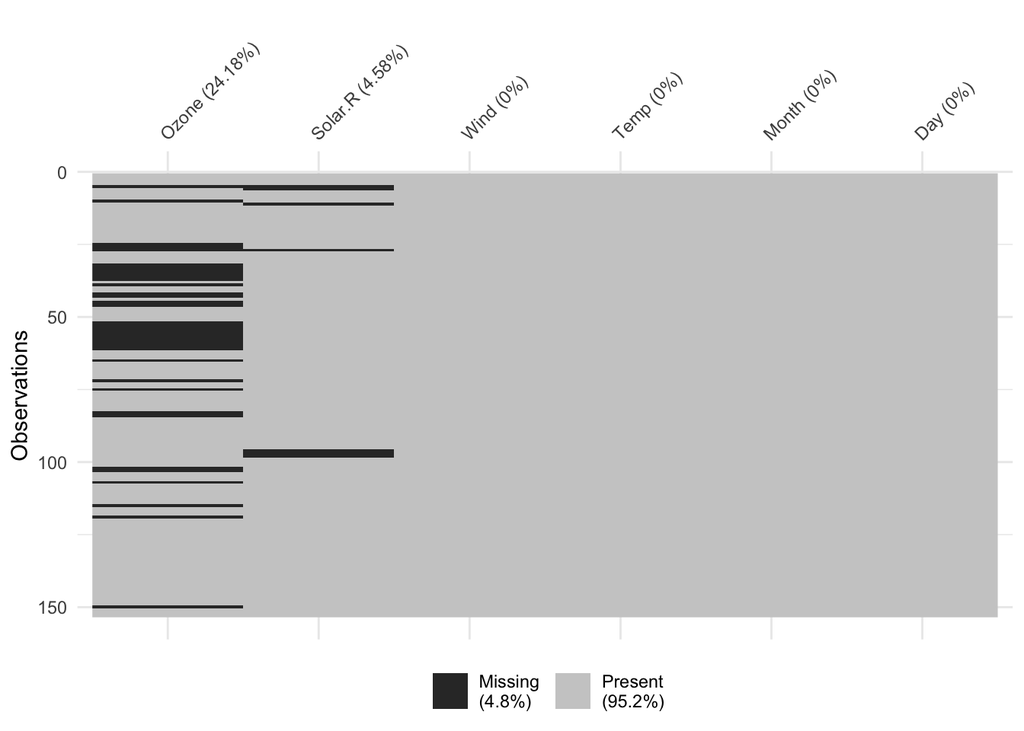

```r
vis_miss(airquality)
```

Чтобы как-то сгрупиировать пропущенные значения можно установить параметр `cluster`.

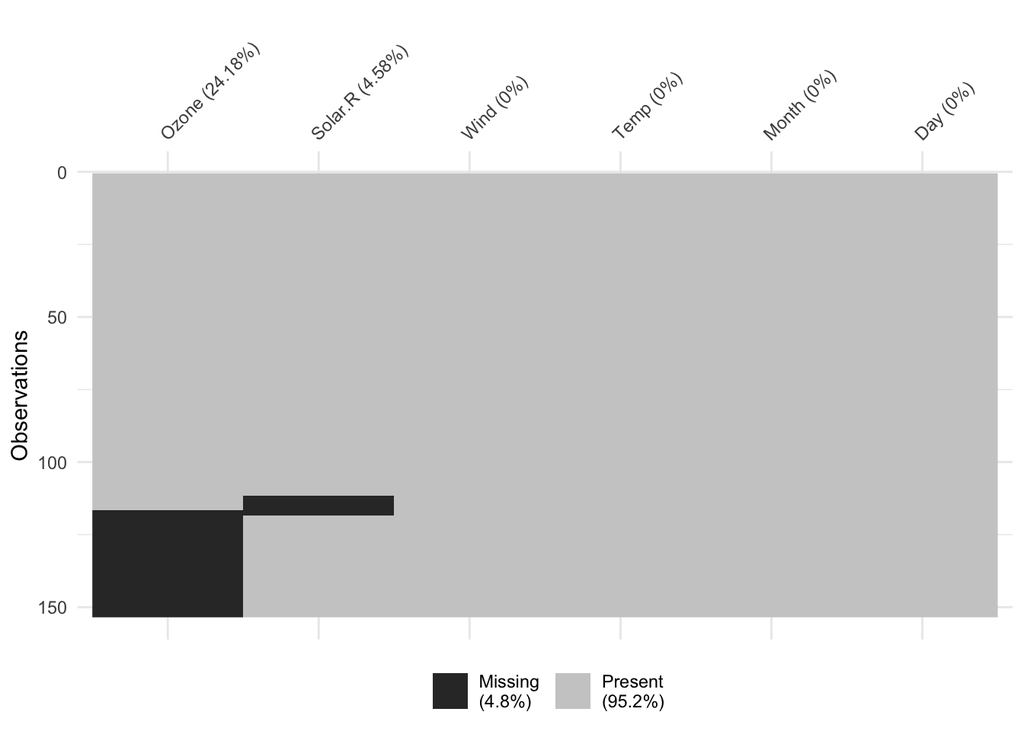

```r
vis_miss(airquality, cluster = TRUE)
```

Попробуем использовать эту функцию на датасете `riskfactors`, в котором больше переменных.

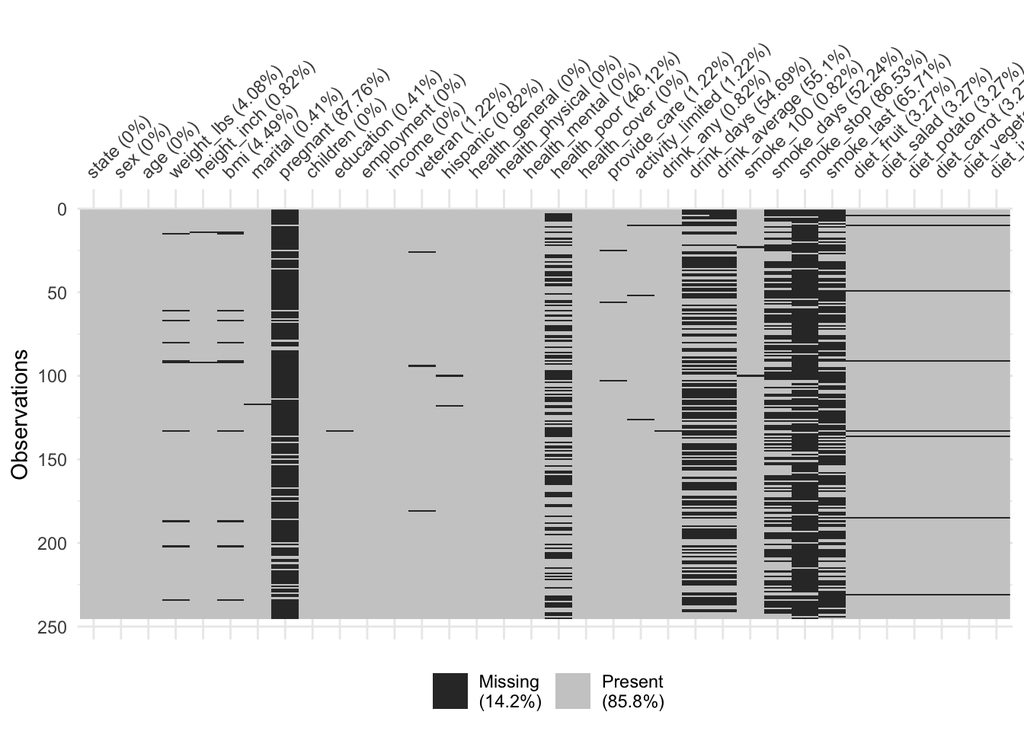

```r
vis_miss(riskfactors)
```

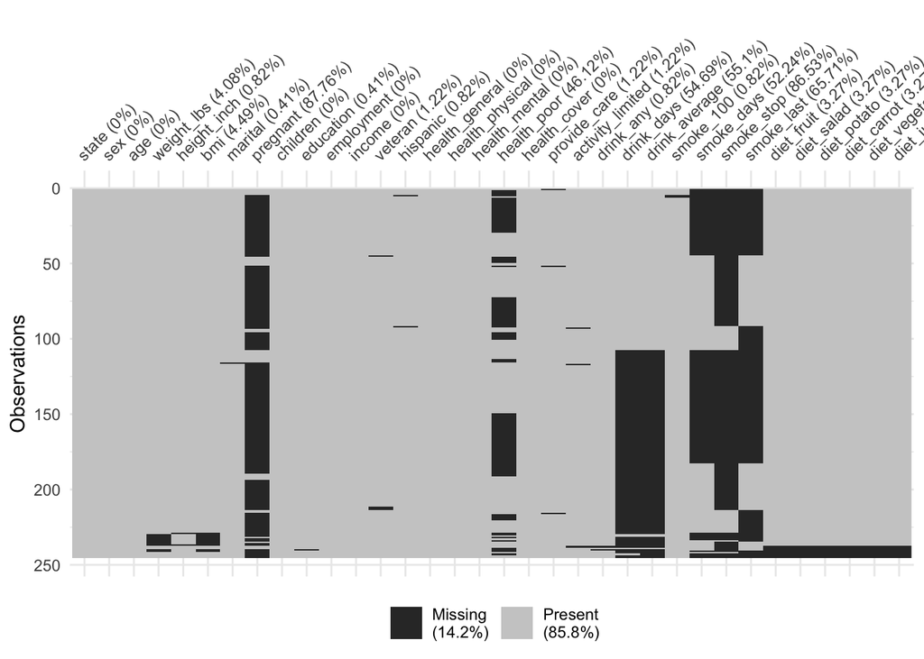

```r
vis_miss(riskfactors, cluster = TRUE)
```

Можно так же отсортировать столбцы по количеству пропущенных значений с помощью параметра `sort`.

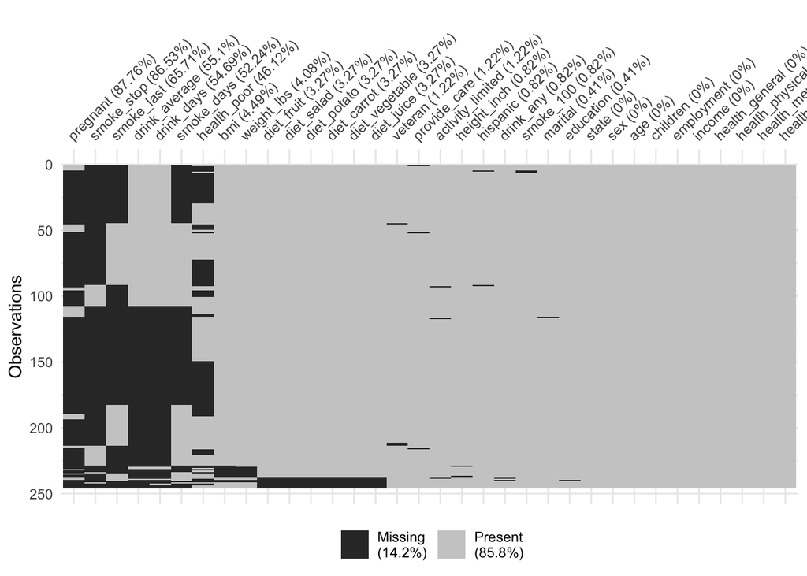

```r
vis_miss(riskfactors, cluster = TRUE, sort = TRUE)
```

#### Функции gg_miss_var и gg_miss_case

Эти функции показывают наглядно количество пропущенных значений в виде гистограмм.

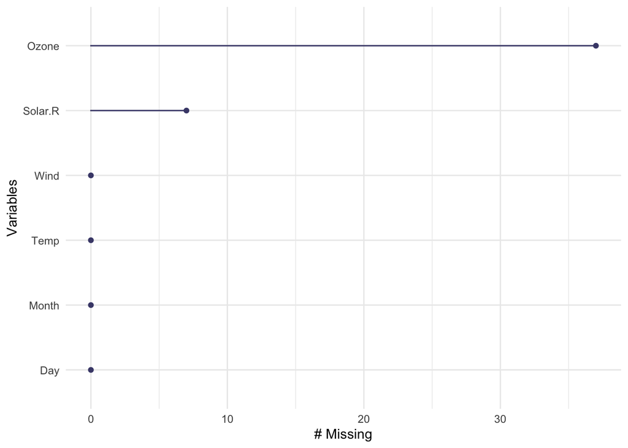

```r
gg_miss_var(airquality)
```

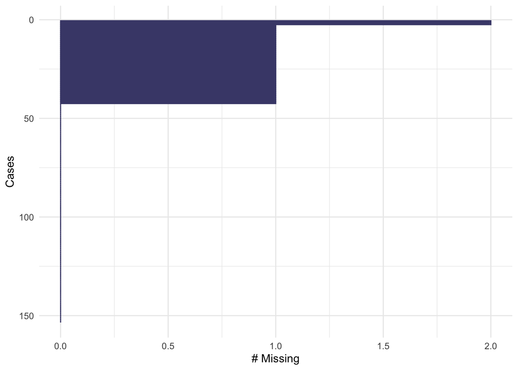

```r
gg_miss_case(airquality)
```

С помощью параметра `facet` можно посмотреть эти графики в разрезе группы.

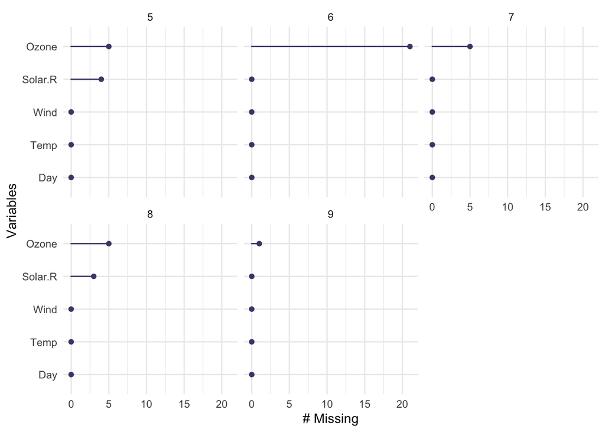

```r
gg_miss_var(airquality, facet = Month)
```

#### Функции gg_miss_upset и gg_miss_fct

Функция `gg_miss_upset` показывает количество пропущенных значений для различных комбинаций переменных.

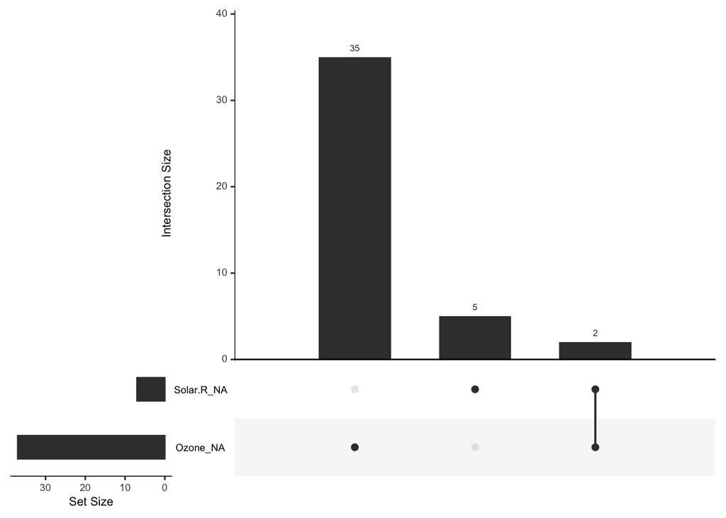

```r
gg_miss_upset(airquality)
```

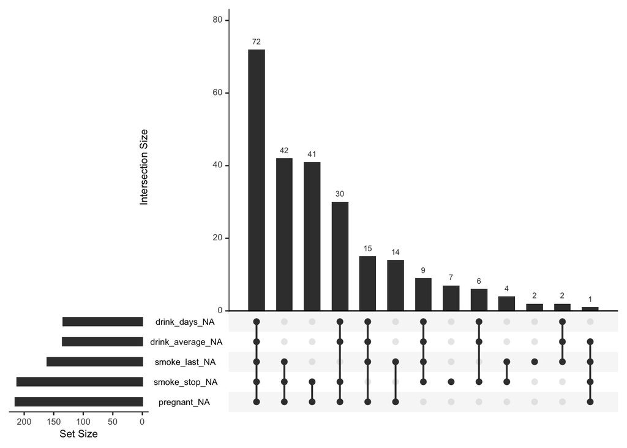

```r
gg_miss_upset(riskfactors)
```

Функция `gg_miss_fct` позволяет увидеть в каких группах и по каким переменным пропущенных значений больше.

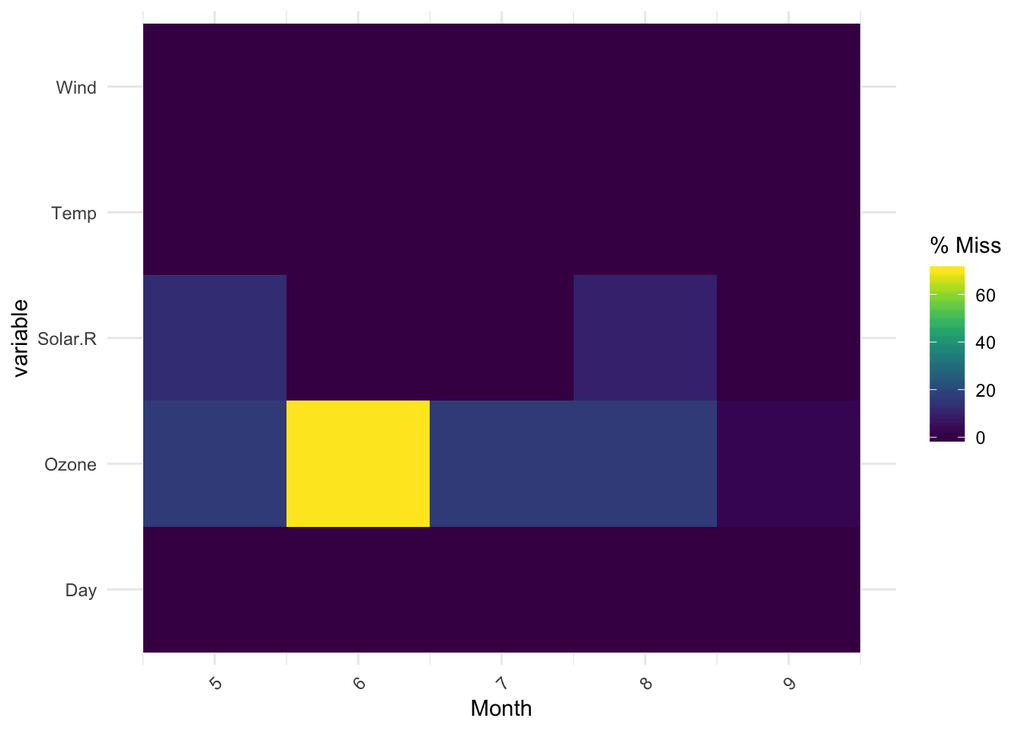

```r
gg_miss_fct(x = airquality, fct = Month)
```

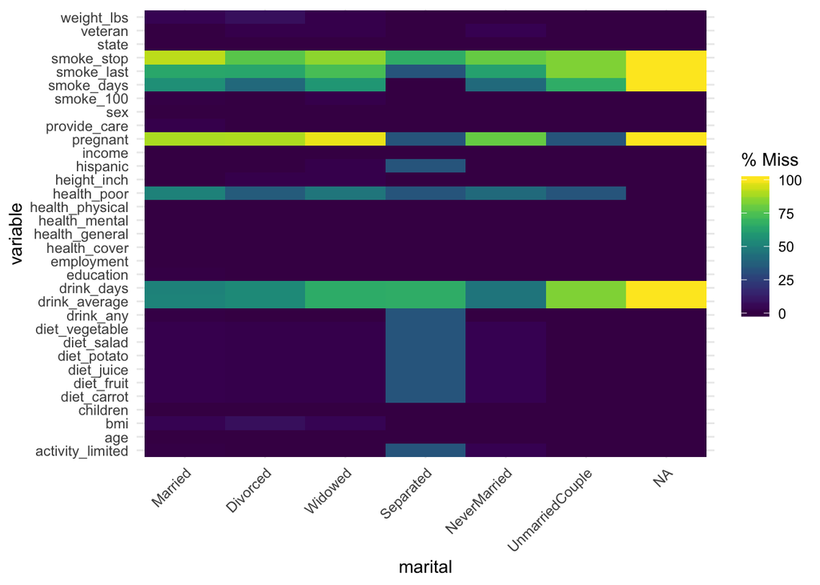

```r
gg_miss_fct(x = riskfactors, fct = marital)
```

### Что делать с пропущенными значениями

Рассмотрим разные случаи при работе с пропущенными значениями.

#### Cлучай №1

Сгенерим набор данных, в котором будет один столбец иметь много пропущенных значений.

```r
df <- tibble(x = generate(0),
             y = generate(0),
             z = generate(0.7))
```

C помощью функции `miss_var_summary` и `vis_miss` посмотрим какие переменные имеют пропущенные значения.

```r
miss_var_summary(df)
```

```
## # A tibble: 3 x 3
##   variable n_miss pct_miss
##   <chr>     <int>    <dbl>
## 1 z           701     70.1
## 2 x             0      0
## 3 y             0      0
```

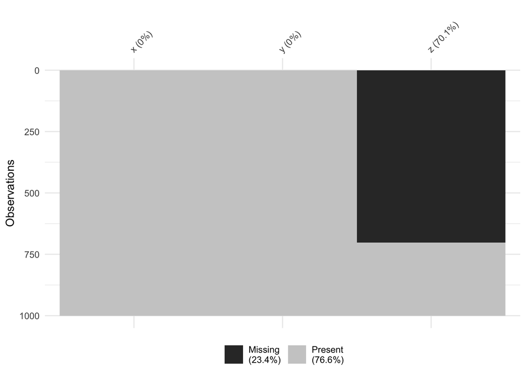

```r
vis_miss(df, cluster = TRUE)
```

```r
df <- df %>%
        select(-z)
```

#### Cлучай №2

Сгенерим набор данных, в котором будет небольшое количество пропущенных значений во всех переменных.

```r
df <- tibble(x = generate(0.05),
             y = generate(0.07),
             z = generate(0.02))
```

C помощью функции `miss_var_summary` и `vis_miss` посмотрим какие переменные имеют пропущенные значения.

```r
miss_var_summary(df)
```

```
## # A tibble: 3 x 3
##   variable n_miss pct_miss
##   <chr>     <int>    <dbl>
## 1 y            74      7.4
## 2 x            42      4.2
## 3 z            20      2
```

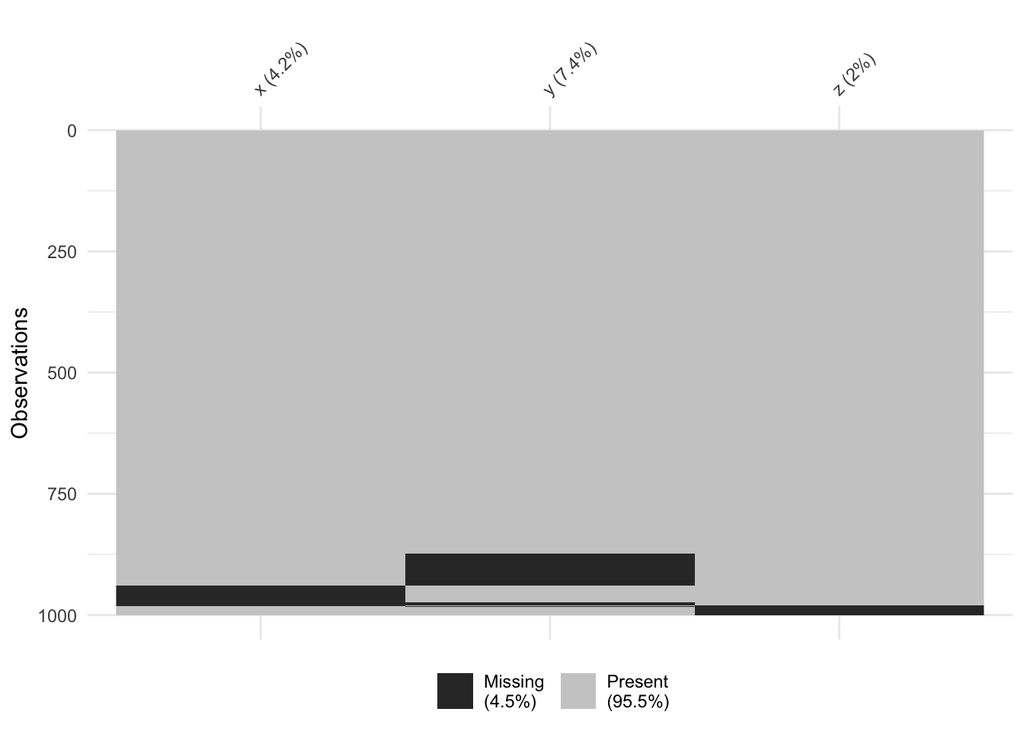

```r
vis_miss(df, cluster = TRUE)
```

```r
miss_case_summary(df) %>%
  filter(n_miss > 0) %>%
  count()
```

```
## # A tibble: 1 x 1
##       n
##   <int>
## 1   128
```

```r
df <- df %>%
        drop_na()
```

#### Замена средним

```r
df <- tibble(x = generate(0.5, 10),
             y = generate(0.3, 10))
df
```

```
## # A tibble: 10 x 2
##         x     y
##     <dbl> <dbl>
##  1 -100    11.1
##  2  -11.1  55.6
##  3   NA   -33.3
##  4   33.3 -55.6
##  5   55.6 -55.6
##  6   NA   100
##  7  -11.1  NA
##  8   NA   -33.3
##  9  -33.3  NA
## 10   NA   -11.1
```

```r
df$x %>% mean(na.rm = TRUE)
```

```
## [1] -11.1111
```

```r
df$x %>% impute_mean()
```

```
##  [1] -100.0000  -11.1111  -11.1111   33.3333   55.5556  -11.1111  -11.1111
##  [8]  -11.1111  -33.3333  -11.1111
```

```r
df %>% impute_mean_if(is.numeric)
```

```
## # A tibble: 10 x 2
##         x      y
##     <dbl>  <dbl>
##  1 -100    11.1
##  2  -11.1  55.6
##  3  -11.1 -33.3
##  4   33.3 -55.6
##  5   55.6 -55.6
##  6  -11.1 100
##  7  -11.1  -2.78
##  8  -11.1 -33.3
##  9  -33.3  -2.78
## 10  -11.1 -11.1
```

```r
df %>% impute_mean_at('x')
```

```
## # A tibble: 10 x 2
##         x     y
##     <dbl> <dbl>
##  1 -100    11.1
##  2  -11.1  55.6
##  3  -11.1 -33.3
##  4   33.3 -55.6
##  5   55.6 -55.6
##  6  -11.1 100
##  7  -11.1  NA
##  8  -11.1 -33.3
##  9  -33.3  NA
## 10  -11.1 -11.1
```

```r
df %>% impute_mean_all()
```

```
## # A tibble: 10 x 2
##         x      y
##     <dbl>  <dbl>
##  1 -100    11.1
##  2  -11.1  55.6
##  3  -11.1 -33.3
##  4   33.3 -55.6
##  5   55.6 -55.6
##  6  -11.1 100
##  7  -11.1  -2.78
##  8  -11.1 -33.3
##  9  -33.3  -2.78
## 10  -11.1 -11.1
```

#### Замена медианой

```r
df$x %>% median(na.rm = TRUE)
```

```
## [1] -11.1111
```

```r
df$x %>% impute_median()
```

```
##  [1] -100.0000  -11.1111  -11.1111   33.3333   55.5556  -11.1111  -11.1111
##  [8]  -11.1111  -33.3333  -11.1111
```

```r
df %>% impute_median_if(is.numeric)
```

```
## # A tibble: 10 x 2
##         x     y
##     <dbl> <dbl>
##  1 -100    11.1
##  2  -11.1  55.6
##  3  -11.1 -33.3
##  4   33.3 -55.6
##  5   55.6 -55.6
##  6  -11.1 100
##  7  -11.1 -22.2
##  8  -11.1 -33.3
##  9  -33.3 -22.2
## 10  -11.1 -11.1
```

```r
df %>% impute_median_at('x')
```

```
## # A tibble: 10 x 2
##         x     y
##     <dbl> <dbl>
##  1 -100    11.1
##  2  -11.1  55.6
##  3  -11.1 -33.3
##  4   33.3 -55.6
##  5   55.6 -55.6
##  6  -11.1 100
##  7  -11.1  NA
##  8  -11.1 -33.3
##  9  -33.3  NA
## 10  -11.1 -11.1
```

```r
df %>% impute_median_all()
```

```
## # A tibble: 10 x 2
##         x     y
##     <dbl> <dbl>
##  1 -100    11.1
##  2  -11.1  55.6
##  3  -11.1 -33.3
##  4   33.3 -55.6
##  5   55.6 -55.6
##  6  -11.1 100
##  7  -11.1 -22.2
##  8  -11.1 -33.3
##  9  -33.3 -22.2
## 10  -11.1 -11.1
```

#### Индикатор пропущенной переменной

Если мы заменяем пропущенное значение средним или медианой, мы в какой-то степени ошибаемся, так как истинное значение могло быть совершенно другим. Чтобы это не мешало модели, можно ввести переменную-индикатор, которая будет равняться 1, если значение заменено.

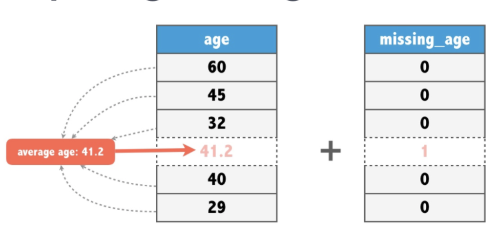

Можно использовать следующую функцию.

```r
ImputeInd <- function(df, strategy = 'mean', column){
  if (strategy == 'mean') {
    df1 <- df %>%
      add_label_missings(column, missing = 1,
                         complete = 0) %>%
      rename(!!paste0(column, '_IND', sep = ''):=any_missing) %>%
      impute_mean_at(column)
    return(df1)
  }
  if (strategy == 'median') {
    df1 <- df %>%
      add_label_missings(column, missing = 1,
                         complete = 0) %>%
      rename(!!paste0(column, '_IND', sep = ''):=any_missing) %>%
      impute_median_at(column)
    return(df1)
  }
  stop('Введите правильно стратегию!')
}
```

Можно использовать даже с *pipe* :)

```r
df %>%
  ImputeInd(strategy = 'mean', 'x') %>%
  ImputeInd(strategy = 'median', 'y')
```

```
## # A tibble: 10 x 4
##         x     y x_IND y_IND
##     <dbl> <dbl> <dbl> <dbl>
##  1 -100    11.1     0     0
##  2  -11.1  55.6     0     0
##  3  -11.1 -33.3     1     0
##  4   33.3 -55.6     0     0
##  5   55.6 -55.6     0     0
##  6  -11.1 100       1     0
##  7  -11.1 -22.2     0     1
##  8  -11.1 -33.3     1     0
##  9  -33.3 -22.2     0     1
## 10  -11.1 -11.1     1     0
```